# Standford Open Policing Project

Lu Zhang

2023-09-13

## Context and Inspiration

The data and context presented here were gathered by https://www.kaggle.com/datasets/faressayah/stanford-open-policing-project.

On an average day in the United States, police officers conduct over 50000 traffic stops. The Standford team is collecting, analyzing, and disseminating data from millions of traffic stops conducted by law enforcement agencies across the country. The project’s purpose is to assist researchers, journalists, and politicians in investigating and improving relations between police and the public.

The tearm is concerned with the following issues:

- Do men or women speed more often?
- Does gender affect who gets searched during a stop?
- During a search, how often is the driver frisked?
- Which year had the least number of stops?
- How does drug activity change by time of day?
- Do most stops occur at night?

## Library set up and data input

```r
library(data.table)
library(tidyverse)
```

```r
library(ggplot2)
```

```r
getwd()
```

```
## [1] "/Users/luzhang/Documents/GitHub/Projects/Traffic stops/Code"
```

```r
dat <- fread("../Data/police_project.csv")
dat <- data.frame(dat)
dim(dat)
```

```
## [1] 91741    15
```

```r
head(dat)
```

```
##    stop_date stop_time county_name driver_gender driver_age_raw driver_age
## 1 2005-01-02     01:55          NA             M           1985         20
## 2 2005-01-18     08:15          NA             M           1965         40
## 3 2005-01-23     23:15          NA             M           1972         33
## 4 2005-02-20     17:15          NA             M           1986         19
## 5 2005-03-14     10:00          NA             F           1984         21
## 6 2005-03-23     09:45          NA             M           1982         23
##   driver_race                  violation_raw violation search_conducted
## 1       White                       Speeding  Speeding            FALSE
## 2       White                       Speeding  Speeding            FALSE
## 3       White                       Speeding  Speeding            FALSE
## 4       White               Call for Service     Other            FALSE
## 5       White                       Speeding  Speeding            FALSE
## 6       Black Equipment/Inspection Violation Equipment            FALSE
##   search_type  stop_outcome is_arrested stop_duration drugs_related_stop
## 1                  Citation       FALSE      0-15 Min              FALSE
## 2                  Citation       FALSE      0-15 Min              FALSE
## 3                  Citation       FALSE      0-15 Min              FALSE
## 4             Arrest Driver        TRUE     16-30 Min              FALSE
## 5                  Citation       FALSE      0-15 Min              FALSE
## 6                  Citation       FALSE      0-15 Min              FALSE
```

```r
colnames(dat)
```

```
##  [1] "stop_date"          "stop_time"          "county_name"
##  [4] "driver_gender"      "driver_age_raw"     "driver_age"
##  [7] "driver_race"        "violation_raw"      "violation"
## [10] "search_conducted"   "search_type"        "stop_outcome"
## [13] "is_arrested"        "stop_duration"      "drugs_related_stop"
```

Let’s go through the questions one by one now!

## Q&As

### Q1 Do men or women speed more often?

```r
Q1 <- dat %>%
  select(driver_gender, violation) %>%
  filter(violation == "Speeding") %>%
  group_by(driver_gender) %>%
  summarize(freq = n())

Q1 <- data.frame(Q1)
Q1
```

```
##   driver_gender  freq
## 1                   2
## 2             F 15482
## 3             M 32979
```

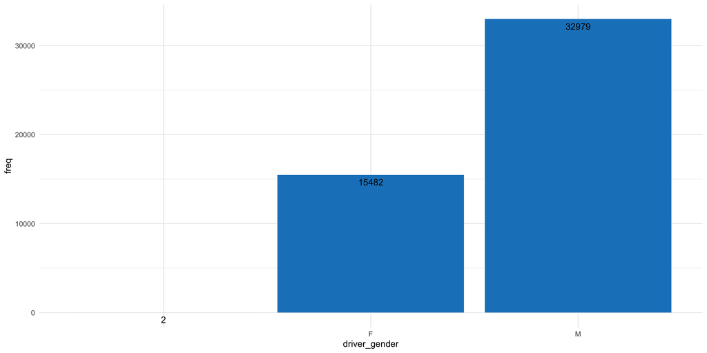

```r
ggplot(data = Q1, aes(x = driver_gender, y = freq))+
  geom_bar(stat="identity", fill = "#1984c5")+
  geom_text(aes(label = freq), vjust = 1.6)+
  theme_minimal()
```

### Q2 Does gender affect who gets searched during a stop?

```r
Q2 <- dat %>%
  select(driver_gender, search_conducted) %>%
  filter(driver_gender %in% c("F","M"))

Q2 <- data.frame(Q2)
```

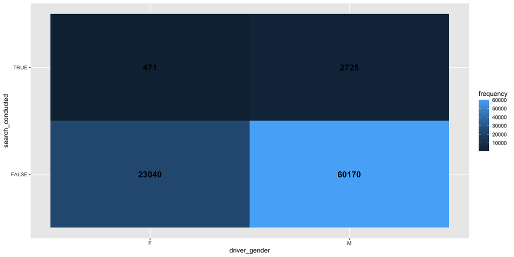

```r
### cross table
crt <- table(Q2$driver_gender, Q2$search_conducted)
#crt

### percentage table
propt <- data.frame(round(prop.table(crt,1),4))
colnames(propt) <- c("driver_gender","search_conducted","percentage")
#propt

### visualization
crt <- data.frame(crt)
colnames(crt) <- c("driver_gender","search_conducted","frequency")

ggplot(crt, aes(x = driver_gender, y = search_conducted))+
  geom_tile(aes(fill = frequency)) +
  geom_text(aes(label = frequency), color = "black", fontface = "bold", size = 5)
```

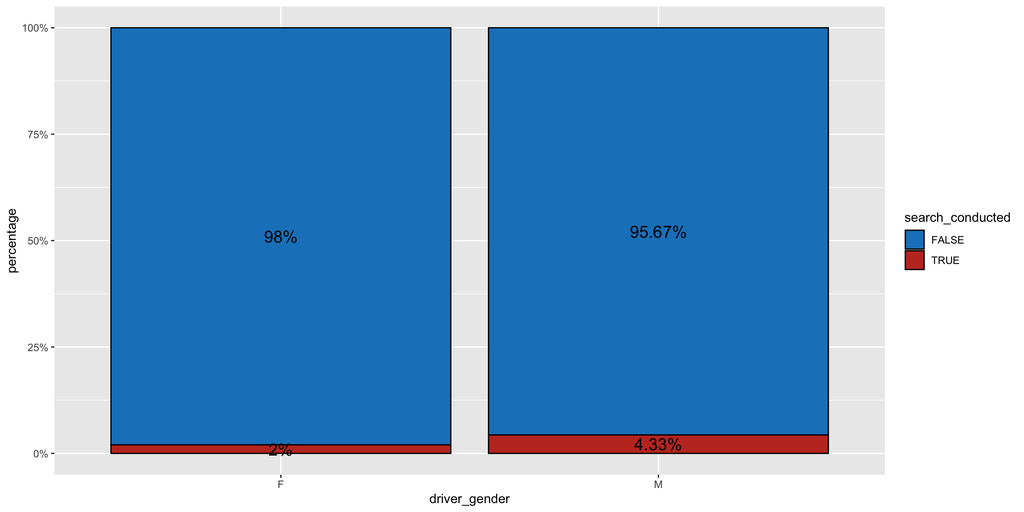

```r
propt$labelpos <- ifelse(propt$search_conducted == "TRUE", propt$percentage/2, 1- propt$percentage/2)

ggplot(dat = propt, aes(x = driver_gender, y = percentage, fill = search_conducted))+
  geom_bar(position = "fill", stat = "identity", color = "black", width = 0.9)+
  scale_y_continuous(label = scales::percent)+
  scale_fill_manual(values = c("#1984c5","#c23728"))+
  geom_text(aes(label = paste0(percentage*100, "%"), y = labelpos),size =5)
```

In the sample of traffic stops, there are 23511 females and 62895 males. During the stop, 471 out of 23511 (about 2%) ladies were searched, while 2725 out of 62895 (approximately 4.33%) males were searched. The chi-square test is used to determine whether there are any significant connections between gender and search behaviors.

```r
chisq.test(Q2$driver_gender, Q2$search_conducted)
```

```
##
##  Pearson's Chi-squared test with Yates' continuity correction
##
## data:  Q2$driver_gender and Q2$search_conducted
## X-squared = 260.02, df = 1, p-value < 2.2e-16
```

The fact that the p value (2.23-16) is smaller than the significance level (0.05) implies that there is a significant relationship between driver gender and search activity. In other words, gender influences who is searched during a stop (If you are interested in how gender influences who is searched during a stop, we can run linear regression. Other factors, such as stop time, driver gender, and so on, might be considered for model accuracy).

### Q3 During a search, how often is the driver frisked?

```r
Q3 <- dat %>%
  filter(grepl('Frisk', search_type))

Q3 <- data.frame(Q3)

#table(Q3$search_type)

frisk_count = length(Q3$search_type)
total_count = length(dat$search_type)
frisk_ratio = frisk_count/total_count

frisk_ratio
```

```
## [1] 0.002986669
```

### Q4 Which year had the least number of stops?

```r
dat$year <- format(dat$stop_date, "%Y")

Q4 <- dat %>%
  group_by(year) %>%
  summarise(freq = n())

Q4 <- data.frame(Q4)
Q4_ordered <- Q4[order(Q4$freq),]
Q4_ordered
```

```
##    year  freq
## 1  2005  2558
## 6  2010  7561
## 5  2009  7908
## 9  2013  7924
## 7  2011  8126
## 11 2015  8599
## 4  2008  8752
## 10 2014  9228
## 3  2007  9476
## 2  2006 10639
## 8  2012 10970
```

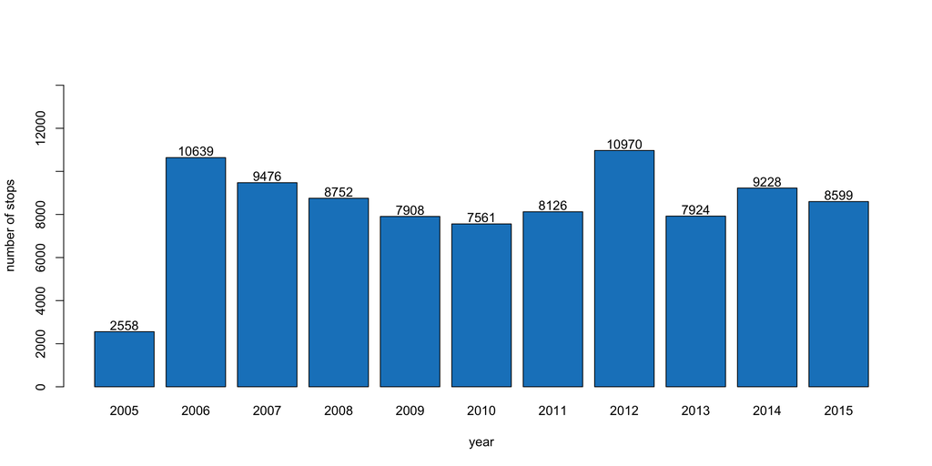

```r
bar_plot <- barplot(Q4$freq,names.arg = Q4$year, xlab = "year", ylab = "number of stops",
                    ylim = c(0,15000),
                    col = "#1984c5")
text(bar_plot, Q4$freq+300, Q4$freq,cex = 1)
```

2005 appears to have had the fewest stops.

### Q5 How does drug activity change by time of day?

```r
#colnames(dat)
#typeof(dat$stop_time)
Hour <- format(strptime(dat$stop_time, format = "%H:%M"), "%H")
#head(Hour)

dat$hour <- Hour

Q5 <- dat %>%
  select(hour, drugs_related_stop) %>%
  filter(drugs_related_stop == "TRUE") %>%
  group_by(hour) %>%
  summarise(freq = n())

Q5 <- data.frame(Q5)
#Q5
```

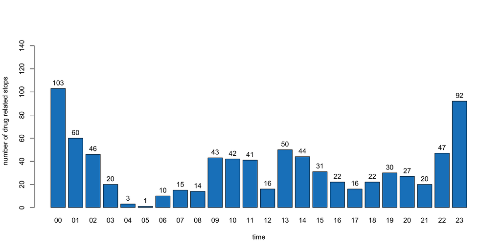

```r
bar_plot2 <- barplot(Q5$freq,names.arg = Q5$hour, xlab = "time", ylab = "number of drug related stops",
                    ylim = c(0,150),
                    col = "#1984c5")
text(bar_plot2, Q5$freq+5, Q5$freq,cex = 1)
```

0i indicates a one-hour interval from 0i:00 to 0i:59, with i = 0, 1,…, 23. For example, 01 signifies 01:00-01:59 AM. According to the bar plot, from 23:00 PM to 00:59 PM, drug activity is at its peak.

### Q6 Do most stops occur at night?

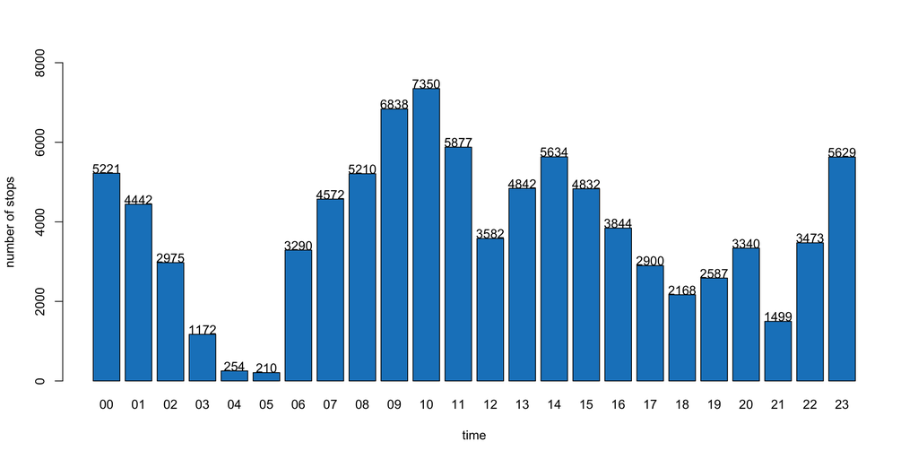

```r
Q6 <- dat %>%
  select(hour) %>%
  group_by(hour) %>%
  summarise(freq_stops = n())

Q6 <- data.frame(Q6)
#Q6

bar_plot3 <- barplot(Q6$freq_stops, names.arg = Q6$hour,
                     xlab = "time", ylab = "number of stops",
                     ylim = c(0,8000),
                     col = "#1984c5")
text(bar_plot3, Q6$freq_stops+120, Q6$freq_stops, cex=1)
```